# Stage 3 Pilot Results — Sponsorship Network

February 13, 2026

# Overview

## Dependent Variables

**Primary DV**: **Trust Change** (Decision 2 - Decision 1)

- Used in RQ1 and RQ4
- Measures how evaluators update their trust after observing an outcome

**Secondary DVs**:

- **Absolute Endorsement Strength** (RQ2): |Rating - 50|, measures sponsor endorsement behavior
- **Initial Trust** (RQ3): Decision 1 trust, measures evaluator’s baseline response to endorsements

## Study Design

Each evaluator sees ONE sponsor making TWO decisions:

1. **Decision 1**: Evaluator sees sponsor endorsement (with strength) $\rightarrow$ stakes X% trust $\rightarrow$ learns outcome (success/failure)
2. **Decision 2**: SAME evaluator sees SAME sponsor on new candidate $\rightarrow$ stakes Y% trust
3. **Trust Change = Y% - X%**

## Research Questions

- **RQ1/HQ1**: Are female sponsors punished **more** for failures and rewarded **less** for successes?
- **RQ2/HQ2**: Do female sponsors provide **weaker** endorsements than male sponsors?
- **RQ3/HQ3**: Do female sponsors need **higher** endorsement strength to achieve same initial trust?
- **RQ4/HQ4**: Is trust change **more** contingent on endorsement strength $\times$ outcome for female sponsors?

## Pilot Sample

| Filter Step | N Remaining |
| --- | --- |
| Total export rows | 277 |
| Exclude preview/incomplete | 271 |
| Valid PROLIFIC_PID | 269 |
| Target study (698e27db580428e78f8e9ff1) | 234 |
| Pass comprehension (Q42=2) | 100 |
| Has condition + Q1 stake | 100 |

```
## Final analytic sample: N = 100
```

```
##   Endorser gender: Man = 48 | Woman = 52
```

```
##   Correctness: Correct = 52 | Incorrect = 48
```

```
##   Strength: Strong = 49 | Weak = 51
```

```
##   Trust change (Q2): N = 100
```

```
##   Median completion: 5.6 min
```

```
##   Gender manipulation check accuracy: 82.6 %
```

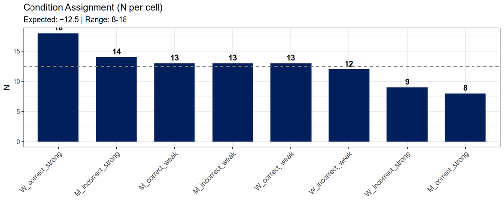

# RQ1: Trust Change by Sponsor Gender $\times$ Protege Outcome

**Hypothesis (HQ1)**: Female sponsors are punished **more** for failures and rewarded **less** for successes.

## Model

$$\text{trust\_change}_{i} = \beta_0 + \beta_1 \texttt{Woman}_{i} +
\beta_2 \texttt{Success}_{i} + \beta_3 (\texttt{Woman}_{i} \times
\texttt{Success}_{i}) + \beta_4 \texttt{abs\_strength\_q1\_c}_{i} +
\epsilon_{i}$$

**Variable definitions:**

| Term in equation | R output name | Levels (reference in parentheses) |
| --- | --- | --- |
| $\texttt{Woman}_{i}$ | `endorser_gender_fWoman` | (**Man** = 0), Woman = 1 |
| $\texttt{Success}_{i}$ | `outcome_fSuccess` | (**Failure** = 0), Success = 1 |
| $\texttt{Woman} \times \texttt{Success}$ | `endorser_gender_fWoman:outcome_fSuccess` | Interaction |
| $\texttt{abs\_strength\_q1\_c}_{i}$ | `abs_strength_q1_c` | Mean-centered |

- $\beta_3$ tests HQ1: negative $\beta_3$ means the success boost is **smaller** for female sponsors

```
##
## Call:
## lm(formula = trust_change ~ endorser_gender_f * outcome_f + abs_strength_q1_c,
##     data = df_tc)
##
## Residuals:
##      Min       1Q   Median       3Q      Max
## -115.269  -20.197   -1.215   23.744   78.210
##
## Coefficients:
##                                         Estimate Std. Error t value Pr(>|t|)
## (Intercept)                              -5.7042     7.4785  -0.763  0.44750
## endorser_gender_fWoman                    3.8979    11.3250   0.344  0.73147
## outcome_fSuccess                         21.6298    11.3558   1.905  0.05984 .
## abs_strength_q1_c                        -0.5026     0.1613  -3.116  0.00243 **
## endorser_gender_fWoman:outcome_fSuccess -16.6779    15.9289  -1.047  0.29775
## ---
## Signif. codes:  0 '***' 0.001 '**' 0.01 '*' 0.05 '.' 0.1 ' ' 1
##
## Residual standard error: 38.84 on 95 degrees of freedom
## Multiple R-squared:  0.1359, Adjusted R-squared:  0.09948
## F-statistic: 3.734 on 4 and 95 DF,  p-value: 0.007246
```

## Interpretation

- **$\beta_0$ (Intercept)**: Mean trust change for **male sponsors after failure**, at average endorsement strength
- **$\beta_1$ (`endorser_gender_fWoman`)**: How much trust change differs for **female sponsors after failure** (relative to male)
- **$\beta_2$ (`outcome_fSuccess`)**: The success boost for **male sponsors** — how much more trust they get after success vs. failure
- **$\beta_3$ (`endorser_gender_fWoman:outcome_fSuccess`)**: **HQ1 test** — how much **smaller** (if negative) the success boost is for female sponsors
- **$\beta_4$ (`abs_strength_q1_c`)**: Controls for the pretreatment strength of the endorsement

## Visualization

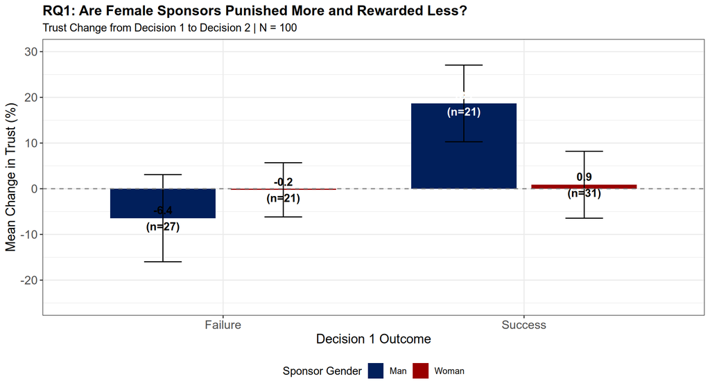

RQ1: Trust Change by Sponsor Gender and Decision 1 Outcome

# RQ2: Endorsement Strength by Sponsor Gender $\times$ Protege Gender

**Hypothesis (HQ2)**: Female sponsors provide **weaker** endorsements than male sponsors.

## Model

$$\text{abs\_strength}_{ij} = \beta_0 + \beta_1
\texttt{Woman\_Sponsor}_{i} + \beta_2 \texttt{Woman\_Protege}_{j} +
\beta_3 (\texttt{Woman\_Sponsor}_{i} \times \texttt{Woman\_Protege}_{j})
+ u_{i} + \epsilon_{ij}$$

**Variable definitions:**

| Term in equation | R output name | Levels (reference in parentheses) |
| --- | --- | --- |
| $\texttt{Woman\_Sponsor}_{i}$ | `endorser_gender_fWoman` | (**Man** = 0), Woman = 1 |
| $\texttt{Woman\_Protege}_{j}$ | `endorsed_gender_fWoman` | (**Man** = 0), Woman = 1 |
| $u_{i}$ | `(1 \| PROLIFIC_PID)` | Random intercept per endorser |

- $\beta_1$ tests HQ2: negative $\beta_1$ means female sponsors give weaker (closer to neutral) endorsements
- Mixed model with random intercepts accounts for 10 repeated trials per endorser

```
## Linear mixed model fit by REML. t-tests use Satterthwaite's method [
## lmerModLmerTest]
## Formula:
## abs_strength ~ endorser_gender_f * endorsed_gender_f + (1 | PROLIFIC_PID)
##    Data: s2_model_data
##
## REML criterion at convergence: 15516
##
## Scaled residuals:
##     Min      1Q  Median      3Q     Max
## -2.5913 -0.8472  0.1647  0.8538  1.6969
##
## Random effects:
##  Groups       Name        Variance Std.Dev.
##  PROLIFIC_PID (Intercept)  36.72    6.06
##  Residual                 228.16   15.11
## Number of obs: 1856, groups:  PROLIFIC_PID, 196
##
## Fixed effects:
##                                                Estimate Std. Error        df
## (Intercept)                                     31.0734     0.9327  391.2249
## endorser_gender_fWoman                           1.3707     1.3359  388.6485
## endorsed_gender_fWoman                          -0.2927     0.9932 1716.1182
## endorser_gender_fWoman:endorsed_gender_fWoman    0.1356     1.4208 1710.2377
##                                               t value Pr(>|t|)
## (Intercept)                                    33.317   <2e-16 ***
## endorser_gender_fWoman                          1.026    0.306
## endorsed_gender_fWoman                         -0.295    0.768
## endorser_gender_fWoman:endorsed_gender_fWoman   0.095    0.924
## ---
## Signif. codes:  0 '***' 0.001 '**' 0.01 '*' 0.05 '.' 0.1 ' ' 1
##
## Correlation of Fixed Effects:
##             (Intr) endrsr__W endrsd__W
## endrsr_gn_W -0.698
## endrsd_gn_W -0.552  0.385
## endr__W:__W  0.386 -0.550    -0.699
```

## Visualization

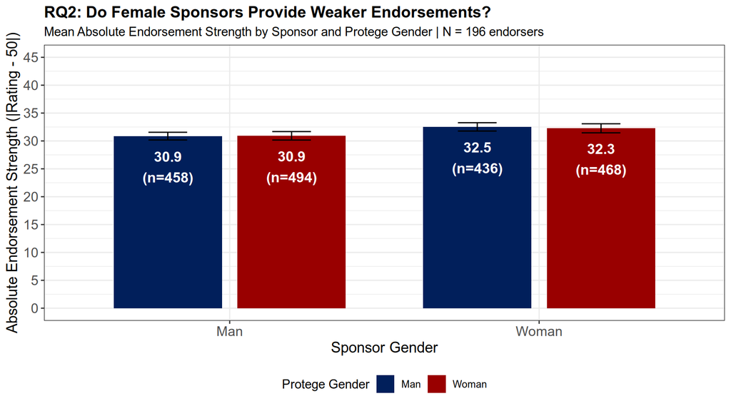

RQ2: Absolute Endorsement Strength by Sponsor and Protege Gender

# RQ3: Initial Trust by Sponsor Gender $\times$ Endorsement Strength

**Hypothesis (HQ3)**: Female sponsors need **higher** endorsement strength to achieve same initial trust as males.

## Model

$$\text{stake\_percent\_q1}_{i} = \beta_0 + \beta_1 \texttt{Woman}_{i} +
\beta_2 \texttt{abs\_strength\_q1}_{i} + \beta_3 (\texttt{Woman}_{i}
\times \texttt{abs\_strength\_q1}_{i}) + \epsilon_{i}$$

**Variable definitions:**

| Term in equation | R output name | Levels / range |
| --- | --- | --- |
| $\text{stake\_percent\_q1}_{i}$ | `stake_percent_q1` | 0–100 (evaluator’s initial trust) |
| $\texttt{Woman}_{i}$ | `endorser_gender_fWoman` | (**Man** = 0), Woman = 1 |
| $\texttt{abs\_strength\_q1}_{i}$ | `abs_strength_q1` |  |

- $\beta_2$: How much initial trust increases per unit of endorsement strength (for **male** sponsors)
- $\beta_3$ tests HQ3: negative $\beta_3$ means female sponsors have a **shallower** slope (need more strength for same trust)

```
##
## Call:
## lm(formula = stake_percent_q1 ~ endorser_gender_f * abs_strength_q1,
##     data = df)
##
## Residuals:
##     Min      1Q  Median      3Q     Max
## -62.053 -15.066   2.704  12.947  53.936
##
## Coefficients:
##                                        Estimate Std. Error t value Pr(>|t|)
## (Intercept)                             46.9769     4.7452   9.900 2.44e-16 ***
## endorser_gender_fWoman                  -1.2392     6.7806  -0.183 0.855380
## abs_strength_q1                          0.5615     0.1401   4.007 0.000121 ***
## endorser_gender_fWoman:abs_strength_q1  -0.2352     0.1942  -1.212 0.228658
## ---
## Signif. codes:  0 '***' 0.001 '**' 0.01 '*' 0.05 '.' 0.1 ' ' 1
##
## Residual standard error: 23.61 on 96 degrees of freedom
## Multiple R-squared:  0.1964, Adjusted R-squared:  0.1713
## F-statistic: 7.821 on 3 and 96 DF,  p-value: 0.0001005
```

## Interpretation

- **$\beta_0$ (Intercept)**: Predicted initial trust for **male sponsors** when abs_strength = 0
- **$\beta_1$ (`endorser_gender_fWoman`)**: Baseline trust difference for female sponsors at zero strength
- **$\beta_2$ (`abs_strength_q1`)**: Slope for **male** sponsors — trust gained per unit of strength
- **$\beta_3$ (`endorser_gender_fWoman:abs_strength_q1`)**: **HQ3 test** — negative means females have a shallower slope

## Visualization

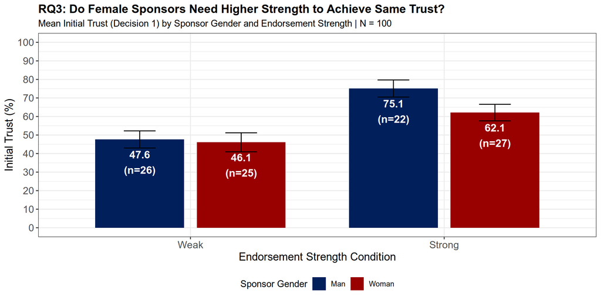

RQ3: Initial Trust by Sponsor Gender and Endorsement Strength

**Observed pattern:**

- At **Weak** endorsement strength, both genders start at similar initial trust (~48% for males, ~46% for females)
- At **Strong** endorsement strength, males receive **75.1%** trust vs. females at **62.1%** — a 13 pp gap
- The strong endorsement “boost” is **27.5 pp** for males but only **16.0 pp** for females
- The interaction is not significant (p = .229), but the direction is consistent with HQ3: female sponsors get less trust per unit of endorsement strength

# RQ4: Trust Change by Gender $\times$ Strength $\times$ Outcome (3-Way Interaction)

**Hypothesis (HQ4)**: Trust change is **more** contingent on endorsement strength $\times$ outcome for female sponsors.

## Model

$$\begin{aligned}
\text{trust\_change}_{i} = \beta_0 &+ \beta_1 \texttt{Woman}_{i} +
\beta_2 \texttt{abs\_str\_c}_{i} + \beta_3 \texttt{Success}_{i} \\
&+ \beta_4 (\texttt{Woman} \times \texttt{abs\_str\_c})_{i} \\
&+ \beta_5 (\texttt{Woman} \times \texttt{Success})_{i} \\
&+ \beta_6 (\texttt{abs\_str\_c} \times \texttt{Success})_{i} \\
&+ \beta_7 (\texttt{Woman} \times \texttt{abs\_str\_c} \times
\texttt{Success})_{i} + \epsilon_{i}
\end{aligned}$$

**Variable definitions:**

| Term in equation | R output name | Levels / range |
| --- | --- | --- |
| $\texttt{Woman}$ | `endorser_gender_fWoman` | (**Man** = 0), Woman = 1 |
| $\texttt{abs\_str\_c}$ | `abs_strength_q1_c` | Mean-centered |
| $\texttt{Success}$ | `outcome_fSuccess` | (**Failure** = 0), Success = 1 |
| $\beta_7$ (3-way) | `endorser_gender_fWoman:abs_strength_q1_c:outcome_fSuccess` |  |

- $\beta_7$ tests HQ4: positive $\beta_7$ means the strength $\times$ outcome interaction is **stronger** for female sponsors

```
##
## Call:
## lm(formula = trust_change ~ endorser_gender_f * abs_strength_q1_c *
##     outcome_f, data = df_tc)
##
## Residuals:
##      Min       1Q   Median       3Q      Max
## -116.197  -19.981   -0.752   23.373   78.477
##
## Coefficients:
##                                                            Estimate Std. Error
## (Intercept)                                                -5.68748    7.60377
## endorser_gender_fWoman                                      4.23782   11.53724
## abs_strength_q1_c                                          -0.51403    0.31242
## outcome_fSuccess                                           21.31287   11.65212
## endorser_gender_fWoman:abs_strength_q1_c                    0.12571    0.47283
## endorser_gender_fWoman:outcome_fSuccess                   -16.57120   16.21807
## abs_strength_q1_c:outcome_fSuccess                         -0.04366    0.47793
## endorser_gender_fWoman:abs_strength_q1_c:outcome_fSuccess  -0.10304    0.66469
##                                                           t value Pr(>|t|)
## (Intercept)                                                -0.748   0.4564
## endorser_gender_fWoman                                      0.367   0.7142
## abs_strength_q1_c                                          -1.645   0.1033
## outcome_fSuccess                                            1.829   0.0706 .
## endorser_gender_fWoman:abs_strength_q1_c                    0.266   0.7909
## endorser_gender_fWoman:outcome_fSuccess                    -1.022   0.3096
## abs_strength_q1_c:outcome_fSuccess                         -0.091   0.9274
## endorser_gender_fWoman:abs_strength_q1_c:outcome_fSuccess  -0.155   0.8771
## ---
## Signif. codes:  0 '***' 0.001 '**' 0.01 '*' 0.05 '.' 0.1 ' ' 1
##
## Residual standard error: 39.44 on 92 degrees of freedom
## Multiple R-squared:  0.1372, Adjusted R-squared:  0.07153
## F-statistic:  2.09 on 7 and 92 DF,  p-value: 0.05234
```

## Visualization

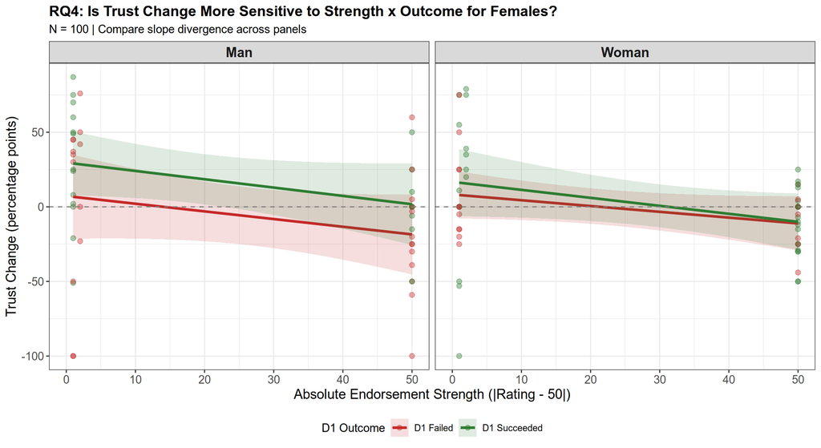

RQ4: Trust Change by Sponsor Gender, Absolute Endorsement Strength, and Outcome

**Observed pattern:**

- The 3-way interaction is not significant (p = .877), indicating that the strength $\times$ outcome relationship does **not** meaningfully differ by sponsor gender
- **All four slope estimates are negative** (ranging from -0.39 to -0.56), meaning that across genders and outcomes, higher endorsement strength is associated with *more negative* trust change
- **Male sponsors** show a large outcome effect (21 pp Success vs. Failure boost, p = .109) but no strength $\times$ outcome interaction within males (p = .935)
- **Female sponsors** show essentially no outcome effect (5 pp boost, p = .635) and no strength $\times$ outcome interaction within females (p = .719)
- The core gender asymmetry from RQ1 persists here — male sponsors’ outcomes matter, female sponsors’ outcomes do not — but this is not moderated by endorsement strength

# Appendix: Robustness — Excluding Manipulation Check Failures

Participants were asked to identify the sponsor’s gender after the task (Q44). Overall accuracy was 82.6%. Below we re-run the main analyses excluding participants who failed this check or did not respond.

```
## Manipulation check pass: N = 76 of 100
```

```
##   Man: 38 | Woman: 38
```

```
##   Excluded: 24 (Man: 10 | Woman: 14 )
```

## Appendix RQ1: Trust Change (Robustness)

```
##
## Call:
## lm(formula = trust_change ~ endorser_gender_f * outcome_f + abs_strength_q1_c,
##     data = df_pass_tc)
##
## Residuals:
##      Min       1Q   Median       3Q      Max
## -111.266  -20.117   -0.532   26.926   88.552
##
## Coefficients:
##                                         Estimate Std. Error t value Pr(>|t|)
## (Intercept)                             -17.4724     9.1429  -1.911   0.0600 .
## endorser_gender_fWoman                   12.2529    14.2517   0.860   0.3928
## outcome_fSuccess                         29.3501    13.3331   2.201   0.0310 *
## abs_strength_q1_c                        -0.4316     0.1935  -2.230   0.0289 *
## endorser_gender_fWoman:outcome_fSuccess -22.9340    19.1946  -1.195   0.2361
## ---
## Signif. codes:  0 '***' 0.001 '**' 0.01 '*' 0.05 '.' 0.1 ' ' 1
##
## Residual standard error: 40.76 on 71 degrees of freedom
## Multiple R-squared:  0.1373, Adjusted R-squared:  0.08874
## F-statistic: 2.826 on 4 and 71 DF,  p-value: 0.031
```

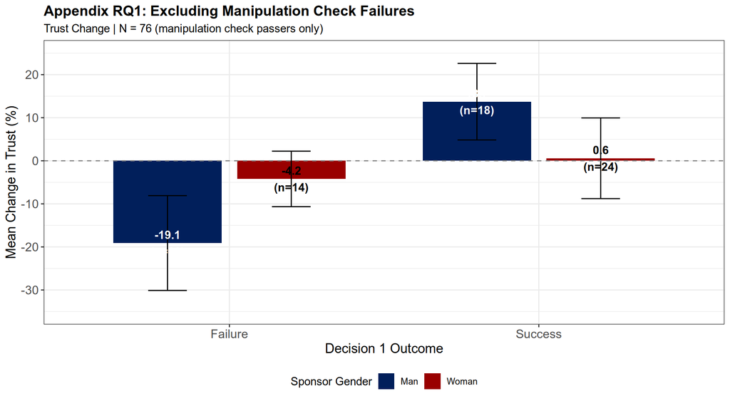

Appendix RQ1: Trust Change — Manipulation Check Passers Only

## Appendix RQ3: Initial Trust (Robustness)

```
##
## Call:
## lm(formula = stake_percent_q1 ~ endorser_gender_f * abs_strength_q1,
##     data = df_pass)
##
## Residuals:
##     Min      1Q  Median      3Q     Max
## -60.284 -18.074   0.849  14.716  51.125
##
## Coefficients:
##                                        Estimate Std. Error t value Pr(>|t|)
## (Intercept)                             49.6573     5.4644   9.087 1.44e-13 ***
## endorser_gender_fWoman                  -1.0154     7.7400  -0.131  0.89599
## abs_strength_q1                          0.4941     0.1587   3.112  0.00266 **
## endorser_gender_fWoman:abs_strength_q1  -0.2612     0.2248  -1.162  0.24913
## ---
## Signif. codes:  0 '***' 0.001 '**' 0.01 '*' 0.05 '.' 0.1 ' ' 1
##
## Residual standard error: 23.87 on 72 degrees of freedom
## Multiple R-squared:  0.1591, Adjusted R-squared:  0.1241
## F-statistic: 4.541 on 3 and 72 DF,  p-value: 0.005687
```

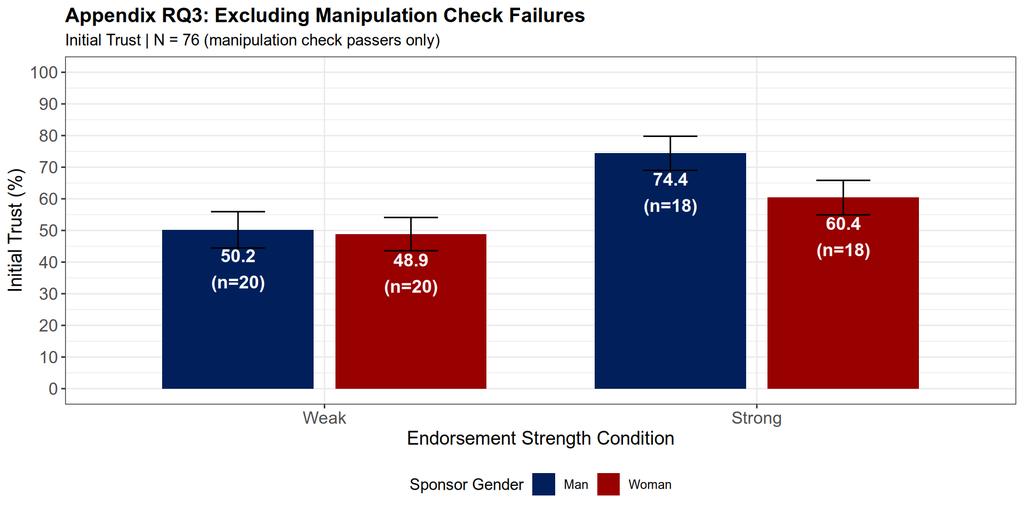

Appendix RQ3: Initial Trust — Manipulation Check Passers Only

## Appendix RQ4: Trust Change 3-Way (Robustness)

```
##
## Call:
## lm(formula = trust_change ~ endorser_gender_f * abs_strength_q1_c *
##     outcome_f, data = df_pass_tc)
##
## Residuals:
##      Min       1Q   Median       3Q      Max
## -117.636  -17.679   -0.571   25.049   83.799
##
## Coefficients:
##                                                            Estimate Std. Error
## (Intercept)                                               -18.29091    9.35853
## endorser_gender_fWoman                                     13.40131   14.52113
## abs_strength_q1_c                                          -0.21455    0.38190
## outcome_fSuccess                                           30.13637   13.62468
## endorser_gender_fWoman:abs_strength_q1_c                   -0.07541    0.59464
## endorser_gender_fWoman:outcome_fSuccess                   -23.68431   19.50421
## abs_strength_q1_c:outcome_fSuccess                         -0.22462    0.55888
## endorser_gender_fWoman:abs_strength_q1_c:outcome_fSuccess  -0.17443    0.80078
##                                                           t value Pr(>|t|)
## (Intercept)                                                -1.954   0.0548 .
## endorser_gender_fWoman                                      0.923   0.3593
## abs_strength_q1_c                                          -0.562   0.5761
## outcome_fSuccess                                            2.212   0.0303 *
## endorser_gender_fWoman:abs_strength_q1_c                   -0.127   0.8995
## endorser_gender_fWoman:outcome_fSuccess                    -1.214   0.2288
## abs_strength_q1_c:outcome_fSuccess                         -0.402   0.6890
## endorser_gender_fWoman:abs_strength_q1_c:outcome_fSuccess  -0.218   0.8282
## ---
## Signif. codes:  0 '***' 0.001 '**' 0.01 '*' 0.05 '.' 0.1 ' ' 1
##
## Residual standard error: 41.35 on 68 degrees of freedom
## Multiple R-squared:  0.1494, Adjusted R-squared:  0.06187
## F-statistic: 1.707 on 7 and 68 DF,  p-value: 0.1221
```

## Appendix Summary: Full Sample vs. Manipulation Check Passers

| Interaction Test | b (Full) | p (Full) | N (Full) | b (Pass) | p (Pass) | N (Pass) |
| --- | --- | --- | --- | --- | --- | --- |
| RQ1: Gender x Outcome | -16.680 | 0.298 | 100 | -22.930 | 0.236 | 76 |
| RQ3: Gender x Strength | -0.235 | 0.229 | 100 | -0.261 | 0.249 | 76 |
| RQ4: 3-way | -0.103 | 0.877 | 100 | -0.174 | 0.828 | 76 |